# Hitler, Trump, Putin and Obama - do they share topics?

Risto Hinno

august 2016

## Introduction

Aim of this article is to analyse topics of Hitler’s, Trump’s, Putin’s and Obama’s speeches. Motivation for this kind of analysis is to find out if topics discussed in speeches differ along different speakers. More precisely to compare topics of more autocratic leaders (Hitler, Putin and Trump) with topics discussed by Obama (who is considered to be more democratic leader). Also dynamics of Hitler’s speeches topics is analysed, because we know many events from his life and certainly he was an interesting figure. Other leaders are still alive and many recent events are just going to be understanded in future because we don’t know how are they going to turn out.

Scale autocratic - democratic is subjective as is topic modelling. Generally people regard Hitler as dictator. For Trump and Putin it might not be so clear. Trump is considered more autocratic because of his sayings (for example to send refugees (not only) back to where they came from). In case of Putin things are also mixed. But Putin is considered autocratic because of his actions in controlling and minimising opposition in Russia and actions in Ukraine which by no means are democratic. Some might say that Obama is not democratic leader (for example frantic critique about Obamacare), but compared to other leaders he is more democratic. He hasn’t suppressed opposition and invaded neighbour contries. At least we could claim that he is more democratic leader than other leaders used in this analysis.

By no means is this study conclusive, on the contrary it has many restrictions. First of all Putin and Hitler speeches are not natively in English. Their speeches have been translated into English. Translations were made by different people, so different words might be used for same topics in different translations which affects the results. Don’t take this article as a truth rather it is a try to understand topic modelling. Also not all speeches of all leaders are analysed, which might also affect final results. It is important to keep in mind that we are comparing different words which means that statistical methods doesn’t give us meaning behind the words.

## Data

Speeches of Hitler are taken from [here](http://www.worldfuturefund.org/wffmaster/Reading/Hitler%20Speeches/Hitler%20Key%20Speeches%20Index.htm) and [here](http://www.hitler.org/speeches/), speeches of Putin [here](http://en.kremlin.ru/events/president/transcripts), speeches of Trump [here](http://www.politico.com/story/2016/07/full-transcript-donald-trump-nomination-acceptance-speech-at-rnc-225974), [here](http://www.p2016.org/photos15/summit/trump012415spt.html) and [here](https://www.donaldjtrump.com/press-releases/donald-j.-trump-foreign-policy-speech). Speeches of Obama are taken from [here](http://www.americanrhetoric.com/barackobamaspeeches.htm).

Speeches of Hitler are following:

```r
library(tm)
docsH <- Corpus(DirSource("./data/Hitler speeches"))
tolower(names(docsH))
```

```
##  [1] "1933, april 8, sportpalast.txt"
##  [2] "1933, february 1, proclamation to the german nation.txt"
##  [3] "1933, february 10, stuttgart.txt"
##  [4] "1933, march 23, official speech on the enabling act to the reichstag.txt"
##  [5] "1933, may 10, congress of the german work front.txt"
##  [6] "1935, may 1, berlin.txt"
##  [7] "1936, september 12, nuremberg labor-front.txt"
##  [8] "1936, september 14, nuremberg.txt"
##  [9] "1937, january 30, speech before the reichstag.txt"
## [10] "1938, november 6, weimar.txt"
## [11] "1938, ocotber 5, sportpalast.txt"
## [12] "1938, october 9, saarbruecken.txt"
## [13] "1938, september 6, nuremberg.txt"
## [14] "1939, april 1, wilhelmshaven.txt"
## [15] "1939, october 6, reichstag.txt"
## [16] "1939, septmber 19, danzig.txt"
## [17] "1940, december 10, rheinmetall-borsig works.txt"
## [18] "1940, january 30, speech at the berlin sportspalast.txt"
## [19] "1941, april 6, hitler's order of the day.txt"
## [20] "1941, february 24, munich.txt"
## [21] "1941, january 30, speech before the reichstag.txt"
## [22] "1941, june 22, hitler's 'barbarossa' proclamation.txt"
## [23] "1941, march 16, zeughaus.txt"
## [24] "1941, may 4, berlin reichstag.txt"
## [25] "1942, january 30, speech at the berlin sportspalast.txt"
```

Speeches of Trump are following:

```r
docsTr <- Corpus(DirSource("./data/Trump speeches"))
tolower(names(docsTr))
```

```
## [1] "2015, january 24, iowa freedom summit .txt"
## [2] "2016, april 27, foreign policy speech.txt"
## [3] "2016, june 16, here’s donald trump’s presidential announcement speech.txt"
```

Speeches of Putin are following:

```r
docsPt <- Corpus(DirSource("./data/Putin speeches"))
tolower(names(docsPt))
```

```
## [1] "2014, december 31, new years speech.txt"
## [2] "2014, march 18, putin crimea speech.txt"
## [3] "2015, december 3, presidential address to the federal assembly.txt"
## [4] "2015, december 31, new years speech.txt"
## [5] "2015, septmber 28, un 70th general assembly.txt"
```

Speeches of Obama are following:

```r
docsOb <- Corpus(DirSource("./data/Obama speeches"))
tolower(names(docsOb))
```

```
## [1] "2015, january 20, remarks by the president in state of the union address.txt"
## [2] "2016, january 13, remarks of president barack obama – state of the union address as delivered.txt"
## [3] "2016, july 27, democratic convention.txt"
```

Biggest number of speeches was chosen for Hitler to see dynamics in time. Trump and Putin are for comparison - are they similar to Hitler speeches and each other? Obama is a control group, if his topics are highly similar to other ones than similarity measure could be questionable. Because there is a huge amount of speeches for Obama and Putin, only ones which try to address whole nation or discuss general topics from previous year(s) were chosen. As author is not an expert in this field conservative choice was made: choose recent speeches found online in English which try to address wider public. So by no means this analysis is exhaustive and choice of speeches might be questionable (and related to my googling skills). An expert could make a better choice. But one note for my justification. It is not very reasonable to include all speeches because many of them address only certain groups (for example speeches for foreign delegations/special events are not probably talking about topics which wider public might not be interested in). For Hitler I didn’t find speeches in English which were addressed only to a narrow group. For Trump speeches which were related to presidential elections were used, because they tended to address general public.

## Data preparation

For data preparation `tm` package was used. Quite usual text cleaning/preparation methods were used:

- make corpus of speeches (already made in previous section)
- remove numbers and punctuation
- remove stopwords
- stemming words

```r
library(dplyr)
TextCleaner=.%>%
  #function to clean/transform corpus of docs; INPUT: docs - corpus of documents; OUTPUT: -corpus of cleaned/transformed documents
    tm_map(content_transformer(tolower))%>%
    tm_map(removeNumbers)%>%
    tm_map(removePunctuation)%>%
    tm_map(removeWords, stopwords("english"))%>%
    tm_map(stripWhitespace)%>%
    tm_map(stemDocument)%>%
    tm_map(content_transformer(function(x,pattern)gsub("ā€™|ā€“"," ", x)))%>%
    tm_map(removeWords, c("don't", "say", "said", "it'", "we'r","—", "don", "applaus"))
#Hitler speeches
docsH=TextCleaner(docsH)
#Trump speeches
docsTr=TextCleaner(docsTr)
#Putin speeches
docsPt=TextCleaner(docsPt)
#Obama speeches
docsOb=TextCleaner(docsOb)
```

## Topic modelling

After data preparation all the corpuses were turned into document-term matrix.

```r
dtmH <- DocumentTermMatrix(docsH)
dtmTr <- DocumentTermMatrix(docsTr)
dtmPt <- DocumentTermMatrix(docsPt)
dtmOb <- DocumentTermMatrix(docsOb)
```

Now topic modelling could begin. For that package `corpustools` was used. This package could be installed from [here](https://github.com/kasperwelbers/corpus-tools). It is a wrapper package which uses functions also from package `lda` (*latent Dirichlet allocation*) which is package for topic modelling. Topic modelling assumes that if somebody writes a text for each topic words are taken from different “bags” of words. So it assumes that for each topic we use different words. More information about lda could be found [here](https://en.wikipedia.org/wiki/Latent_Dirichlet_allocation). In model we could adjust 2 parameters:

- K - number of topics
- alpha - how “clear” topics do we want (the smaller the number the “clearer” the topics are)

For the purpose of gaining clear topics alpha was chosen to be 0.3 (it could be at minimum 0, at maximum 1). Number of topics were chosen based on visualization using package `LDAvis` and clarity of topics. K was chosen to be minimum number of topics in which topics did not overlap in LDAvis visualization. In case visually topics did not overlap, but seemed to be mixed, number of topics was increased by one. This is also a step which is very subjective and might be easily criticized. There are also other, more mathematical [ways](https://cran.r-project.org/web/packages/ldatuning/vignettes/topics.html) to calculate number of topics. In reality they estimate too many topics to interpret in practice.

LDAvis produces .html interactive visualisations which could be viewed with browser. Links to visualisations are provided in the text.

For Hitler’s speeches K=5 was biggest value when topics did not overlap. 10 most popular words representing topics are following:

```r
library(corpustools)
set.seed(1)
#Hitler
ldaH = lda.fit(dtmH, K=5, alpha=.3)
#run it once, helps to make separate folder for vis to upload it to the web
invisible(lapply(
    file.path("https://raw.githubusercontent.com/trinker/topicmodels_learning/master/functions",
      c("topicmodels2LDAvis.R", "optimal_k.R")),devtools::source_url))
#interactive visualization
library(LDAvis)
ldaH %>%
  topicmodels2LDAvis() %>%
  LDAvis::serVis(out.dir = './visualisations/Hitler ldavis', open.browser = F)
#10 terms of each topic
as.data.frame(terms(ldaH,10))
```

```
##    Topic 1 Topic 2   Topic 3  Topic 4 Topic 5
## 1   german     war      will   nation   peopl
## 2    reich  german      year    state     can
## 3     forc   world    govern   german    will
## 4     peac    time socialist  germani     one
## 5    howev germani      life   econom    must
## 6     armi    year     place  countri   great
## 7   attack   today   revolut   intern    make
## 8   polish   peopl      work      may    live
## 9     thus    will     world interest   parti
## 10  govern     now necessari    exist   never
```

LDAvis visualisation for his topics is [here](http://rristo.github.io/HTPO_topics/Hitler%20ldavis/index.html). For Hitler topics names were chosen to be as following:

```r
Htopics=c("German army", "War", "Life/work", "State/economy", "People can")
```

This is also one weakness of topic modelling. You don’t know the names of the topics and knowing background of the text might help you to understand (if topics are clear or fuzzy) and name the topics more accurately.

For Trump K=6 was maximum which satisfied non overlapping condition. 10 most popular words representing topics are following:

```r
#Trump
set.seed(1)
ldaTr = lda.fit(dtmTr, K=6, alpha=.3)
#visualize
library(LDAvis)
ldaTr %>%
  topicmodels2LDAvis() %>%
  LDAvis::serVis(out.dir = './visualisations/Trump ldavis', open.browser = F)
#10 terms of each topic
as.data.frame(terms(ldaTr,10))
```

```
##    Topic 1 Topic 2 Topic 3  Topic 4  Topic 5  Topic 6
## 1    peopl    just    they     make     will    world
## 2     know     get     ā€     will     must   presid
## 3      can    mani     get     need   polici militari
## 4    great    year    good     take  america   friend
## 5      now    cant   right      job  foreign    obama
## 6    build    like    back interest american     even
## 7  countri    mean    like     tell     alli    trade
## 8      one    dont    want  countri     goal      new
## 9    china   secur     big     deal     look    state
## 10   thing    talk    that     time     also    alway
```

LDAvis visualisation for his topics is [here](http://rristo.github.io/HTPO_topics/Trump%20ldavis/index.html). His topics were named as following:

```r
Trtopics=c("People know","Elections", "Security","Make America great", "Foreign policy", "World")
```

For Putin K=3 was maximum which satisfied non overlapping condition, but as his topics were mixed (two topics talking about Ukraine), number of topics was chosen to be 4. 10 most popular words representing topics are following:

```r
set.seed(1)
ldaPt = lda.fit(dtmPt, K=4, alpha=.3)
#visualize
library(LDAvis)
ldaPt %>%
  topicmodels2LDAvis() %>%
  LDAvis::serVis(out.dir = './visualisations/Putin ldavis', open.browser = F)
#10 terms of each topic
as.data.frame(terms(ldaPt,10))
```

```
##     Topic 1 Topic 2 Topic 3 Topic 4
## 1    russia   state    like    will
## 2     peopl  nation countri    must
## 3    crimea    will    make    year
## 4   russian  intern  govern develop
## 5       one     now  region    busi
## 6    ukrain   decis    also  import
## 7   support   right     can    work
## 8      time   world    know  includ
## 9     today   howev  econom    need
## 10 interest  situat    issu   feder
```

LDAvis visualisations for Putin’s topics is [here](http://rristo.github.io/HTPO_topics/Putin%20ldavis/index.html). His topics were named as following:

```r
Pttopics=c("Ukraine","State/nation","Internal issues", "Busy year")
```

For Obama K=3 was maximum which satisfied non overlapping condition, but again this included topics that were sharing common theme, K was cosen to be 4. 10 most popular words representing topics are following:

```r
set.seed(1)
ldaOb = lda.fit(dtmOb, K=4, alpha=.3)
#visualize
library(LDAvis)
ldaOb %>%
  topicmodels2LDAvis() %>%
  LDAvis::serVis(out.dir = './visualisations/Obama ldavis', open.browser = F)
#10 terms of each topic
as.data.frame(terms(ldaOb,10))
```

```
##    Topic 1 Topic 2 Topic 3  Topic 4
## 1  america    year    know american
## 2      can    work    just     make
## 3     like   peopl    that    world
## 4   famili     new  better      job
## 5      one    will    even     need
## 6  economi   everi     see     want
## 7     help countri hillari      now
## 8    thing   chang     got     that
## 9   nation   right     kid      let
## 10    keep    time    vote     back
```

LDAvis visualisation for Obama’s topics is [here](http://rristo.github.io/HTPO_topics/Obama%20ldavis/index.html). His topics were named as following:

```r
Obtopics=c("Internal issues", "Work for change", "Elections", "Foreign issues")
```

## Dynamics of Hitler’s topics

Before comparing topics, it is reasonable to look how topic popularity has been changing in time. Because Hitler is interesting (you could use some other word here) figure and we know many events that shaped his life, we would like to see if topic popularities changed in time. Also it is relatively easy to gain quite representative amount of Hitler’s speeches for analysis. To visualize topics dynamics we have to process the data. We have to get each topic popularity (probability) in each year relative to other topics (we assume that Hitler talked about maximum 5 previously identified topics in each year between 1933-1942).

```r
library(reshape2)
library(ggplot2)
library(plotly)
p=ldaH%>% ##calculate each topic median in each year and plot it
  topicmodels::posterior()%>% #get posterior probabilities
  with(topics)%>% #select list element topics
  as.data.frame(na.rm=T)%>% #turn into df
  `colnames<-`(Htopics)%>% #add topics names
  cbind(year=gsub(", .*$","", names(docsH)))%>% #add the year
  melt()%>% #turn into long format
  group_by(year, variable)%>% #group by year and topic
  summarise(median=median(value))%>%
  `colnames<-`(c("year", "Topic","median"))%>%
  ggplot(., aes(x=year, y=median, colour=Topic, group=Topic))+ #plot it
  geom_line()+
  theme_minimal()+
  theme(axis.text.x = element_text(angle=90))+
  xlab("year")+
  ylab("Topic popularity")
ggplotly(p)
```

[interactive chart not shown]

As seen from the plot topic popularity looks volatile. One reason might be that different years have different number of speeches which affects which topic is more popular. But also it looks like topics popularities vary in time:

- Topic “German army” was more popular in 1939 (beginning of the World War 2) and in 1941 (invasion of the Soviet Union). Which is pretty logical.
- We also see that topic “War” has been quite popular in all of the timeframe but it’s popularity has been rising when World War II started.
- From the plot it is seen that topic “Life/work” popularity declined before the World War II started and has stayed on the low level. Which again is pretty logical. As war (and preparations to it) progressed difficult coiches had to be made to support the war machine which meant that life quality and working conditions were not priority
- There also seems to be decline in popularity of topic “State/economy” but not as much as in topic “Life/work”.
- There also seems to be slight decline in topic “People can”. But due to big fluctuations it is difficult be certain.

One note for caution. All my conclusions are based on my limited knowledge of Hitler and his speeches. If trends would have been upside down (for example topic “War” would have been more popular before World War II) I would have found reasonable explanation to it. At most it is preliminary study for more solid analysis.

## Topic similarity

To compare topics I use cosine similarity (from `lsa` package). It is in many cases used to calculate similarity between two texts. Cosine similarity was used because it is simple to calculate and also because it is pretty popular. What you need is words from each text with their frequencies. Example calculation could be found [here](https://bioinformatics.oxfordjournals.org/content/suppl/2009/10/24/btp613.DC1/bioinf-2008-1835-File004.pdf). There are other measures of similarity, but cosine similarity was used for it’s simple usage. For example Euclidean distance was not used because it’s results didn’t give much information (scores were between 0.09-0.014). It is reasonable, because cosine distance measures directional similarity but Euclidean distance measures magnitude ([link](http://semanticvoid.com/blog/2007/02/23/similarity-measure-cosine-similarity-or-euclidean-distance-or-both/)). As for this calculation I used normalized posterior word probabilities magnitude doesn’t have a wide scale to change (min 0, max 1, in reality much lower than 1).

As mentioned to calculate similarity between two topics I didn’t use word frequencies but word posterior probability. Each word has in each person’s each topic different probability. When two topics from two different persons have high cosine similarity than these topics are similar. This means that first they share bigger amount of words and that also words have similar probabilities.

First let’s compare Hitler’s topics with Trump’s ones:

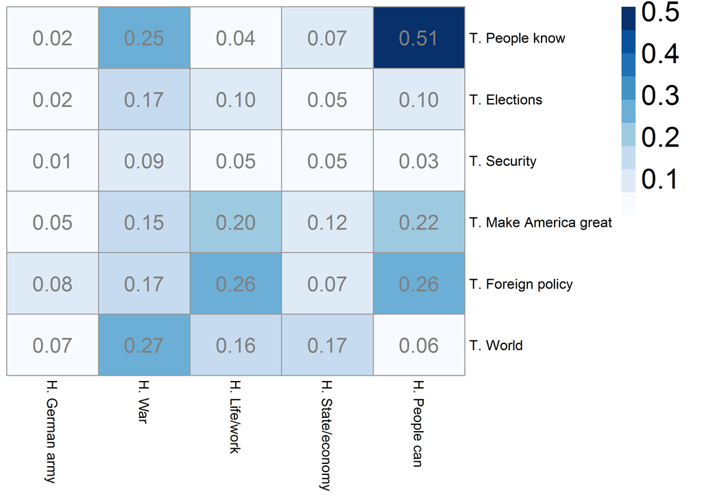

```r
library(lsa)
library(pheatmap)
poster=.%>% #helper function to get posterior probs, turn into df and add terms col
  topicmodels::posterior()%>% #get posterior probabilities
  with(terms)%>% #select list element terms
  as.data.frame(na.rm=T)%>% #turn into df
  t()%>% #transpose
  as.data.frame()%>%
  mutate(term=row.names(x=.))
CosineSim=function(lda1, lda2,name1=NA, name2=NA, long=F) {
  #function to compute topic similarity based on cosine similarity; INPUT: 2 LDA models which topics are compared; name1, name2=(char) names of speakers; long (boolean) result in long format (only in long fromat are the names needed; OUTPUT: dataframe of two LDAs topic similarities based on cosine similarities
  posterior1=poster(lda1)
  posterior2=poster(lda2)
  merged=merge(posterior1, posterior2, by.x = "term",by.y="term", all = T) #merge two data frames
  merged[is.na(merged)]=0 #replace NAs with 0
  ncolPos1=ncol(posterior1)-1 #nr of topics
  ncolPos2=ncol(posterior2)-1
  mat=data.frame(NULL)
#loop through and claculate mat/df of cosine similarities
  for (y in 1:ncolPos2) {
    for (x in 1:ncolPos1) {
      mat[y, x]=as.data.frame(cosine(merged[,y+1+ncolPos1], merged[,x+1]))
    }
    }
  result=data.frame(mat)%>% #add col and row names
    `colnames<-`(paste0("topic",1:ncolPos1, deparse(substitute(lda1))))%>%
    `rownames<-`(paste0("topic",1:ncolPos2, deparse(substitute(lda2))))
  #if long format=T, turn into long format and add name col
  if(long==T) {
    result=result%>%
      melt()%>%
      mutate(Speakers=paste(name1,"vs", name2))
  }
  result
  }
#function to call previous function and to make a plot
CosSimPlot=function(lda1, lda2, topics1, topics2, abbrev1, abbrev2) {
  #function to make heatmap based on two LDA models probabilities; INPUT: - lda1, lda2: 2 LDA models (lda()) which topics are compared;- topics1, topics2: (character vector) manually named topics for two models; - abbrev1, abbrev2: short names for specifiyng names of datasets, will be pasted to topics to make better difference on plot; OUTPUT: - heatmap
  colours <- c('#f7fbff','#deebf7','#c6dbef','#9ecae1','#6baed6', '#4292c6','#2171b5','#08519c','#08306b')
  CosineSim(lda1, lda2)%>% #calculate cosine similarity
    `colnames<-`(paste(abbrev1,topics1))%>%
    `rownames<-`(paste(abbrev2,topics2))%>%
    pheatmap(cluster_rows = F, cluster_cols = F, display_numbers = T,color=colours,fontsize=20,
             fontsize_number=15, number_color="grey50", fontsize_col = 10, fontsize_row = 10)
  }
#Hitler vs Trump
CosSimPlot(ldaH, ldaTr, Htopics,Trtopics, "H.", "T.")
```

As seen from the heatmap Hitler and Trump have highest cosine similarity in people related topic (Hitler: “People can”, Trump: “People know”, cosine similarity=.51). On average similarity is pretty low. We could [compare](https://cran.r-project.org/web/packages/lsa/lsa.pdf) values of cosine similarity with Pearson correlation values which means that similarity measure is pretty low (correlation about .3-.4 is a weak correlation).

Cosine similarity heatmap for Hitler’s and Putin’s topics are:

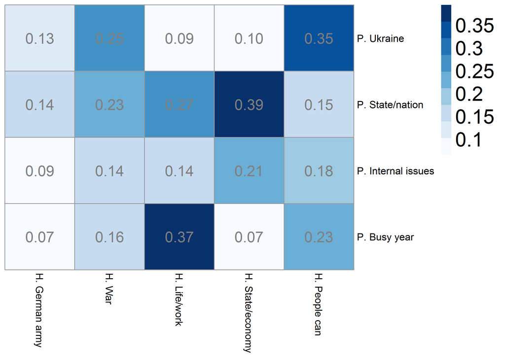

```r
CosSimPlot(ldaH, ldaPt, Htopics,Pttopics, "H.", "P.")
```

As seen from the heatmap most similar are state related topics (Hitler: “State/economy”, Putin: “State/nation”, cosine similarity=.39). Also Putin’s “Busy year” and Hitler’s “Life/work” seem to be more highly similar than most topics (cosine similarity=.37). It might be that both topics talk about daily life issues. Interesting is that Putin’s topic “Ukraine” is similar to Hitler’s topic “People can” (cosine similarity=.35).

Cosine similarity heatmap for Hitler’s and Obama’s topics are:

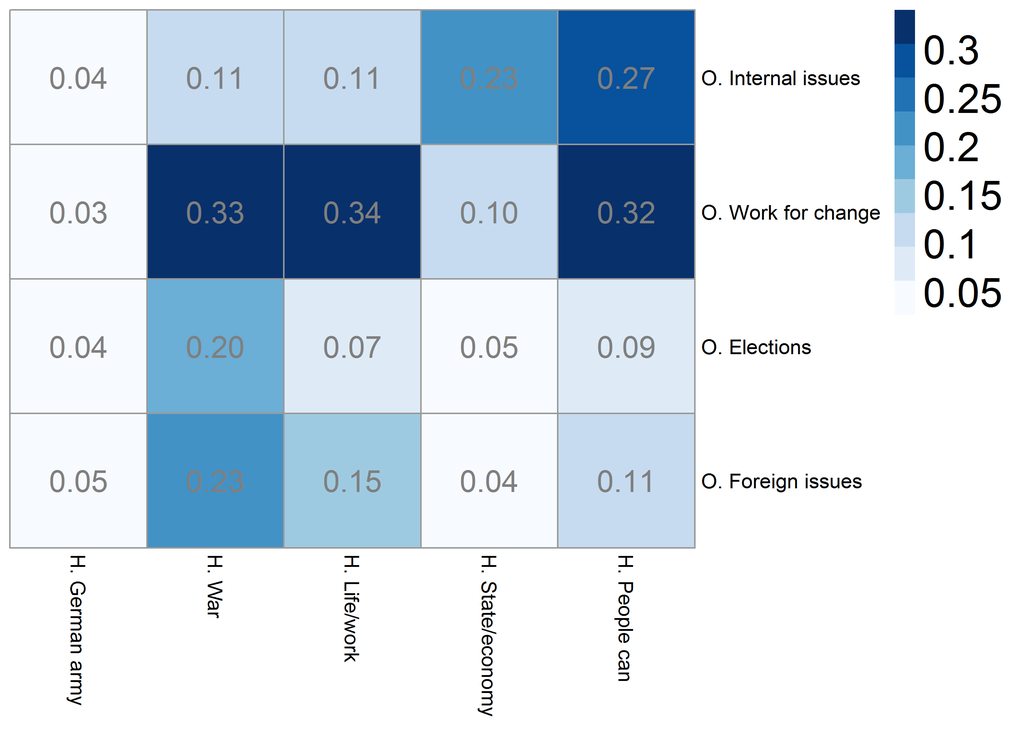

```r
CosSimPlot(ldaH, ldaOb, Htopics,Obtopics, "H.", "O.")
```

Highest cosine similarity is a little bit lower than was for previous comparisons. But it is interesting that Obama’s topic “Change” in more similar to Hitler’s many topics (similarity is higher than average): “War” (cosine similarity=.33), “Life/work” (cosine similarity=.34), “People can” (cosine similarity=.32). We could discuss why it is so. One reason might be that three topics of Hitler regard change and use similar words. But it must be bear in mind that Hitler’s text are translated and we don’t really analyse deeper meaning behind those words.

Cosine similarity heatmap for Trump’s and Putin’s topics are:

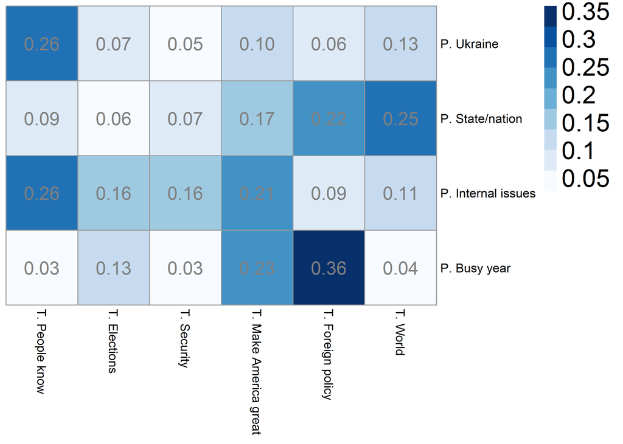

```r
CosSimPlot(ldaTr, ldaPt, Trtopics,Pttopics, "T.", "P.")
```

In this heatmap we see that Trump’s topic “Foreign policy” is more similar to Putin’s topic “Busy year” (cosine similarity=.36). We could speculate that “Busy year” is related to foreign policy (economic restrictions, actions in Ukraine).

Cosine similarity heatmap for Putin’s and Obamas’s topics are:

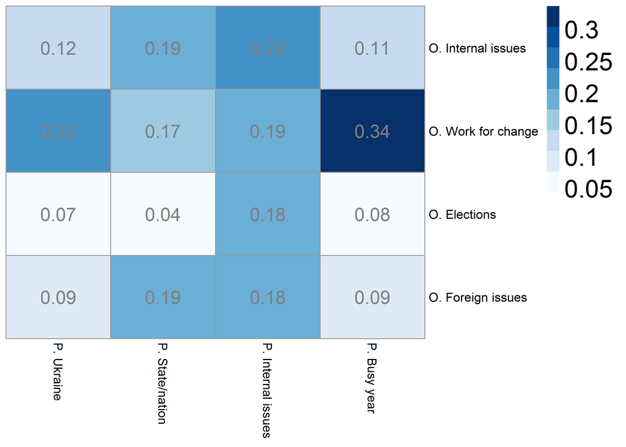

```r
CosSimPlot(ldaPt, ldaOb, Pttopics,Obtopics, "P.", "O.")
```

From the heatmp we could see that Obama’s topic “Work for change” is more similar to Putin’s topic “Busy year” (cosine similarity=.34) than are other topics. Again we could speculate that both topics are related to change.

Cosine similarity heatmap for Trump’s and Obamas’s topics are:

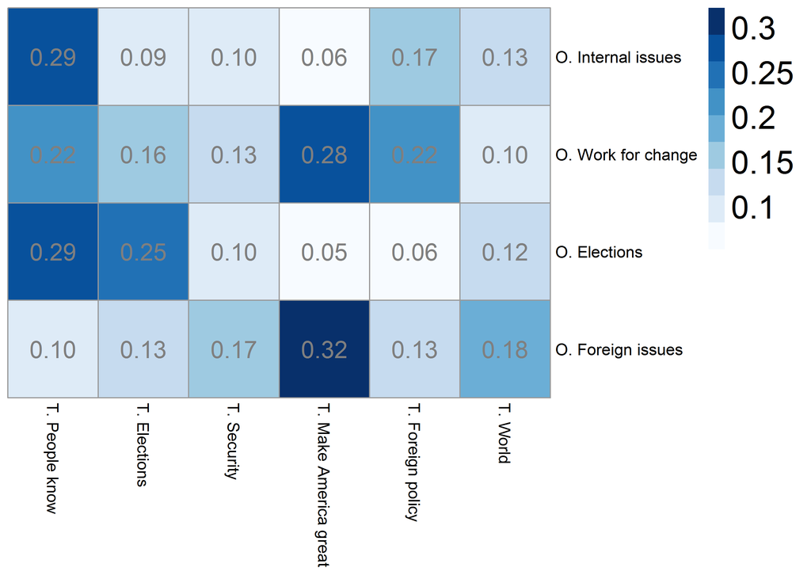

```r
CosSimPlot(ldaTr, ldaOb, Trtopics,Obtopics, "T.", "O.")
```

From the plot we could see that Obama’s topic “Foreign issues” is more similar to Trump’s topic “Make America great” (cosine similarity=0.32) than to other topics. They might be related because Trump might see foreign issues as one cause why America is not yet a great/way to make America great.

To see if there are significant differences between different speakers (all comparisons comdined into one dataset) boxplot is used.

```r
library(data.table)
#list of ldaS
ldas=list(Hitler=ldaH, Trump=ldaTr, Putin=ldaPt, Obama=ldaOb)
indexis=ldas%>%
  length()%>%
  seq()%>%
  expand.grid(dtm1=.,dtm2=.)%>%  #all combinations of indexis
  apply(1,sort)%>% #sort
  t()%>%
  unique()%>% #keep unique combinations
  as.data.frame()%>%
  filter(V1!=V2) #remove where on one row two columns have same value
#make comparions into a list
comp=lapply(seq_along(indexis[,1]), function(i) CosineSim(lda1 =ldas[[indexis[i,1]]],
lda2 = ldas[[indexis[i,2]]],name1 = names(ldas)[indexis[i,1]], name2 = names(ldas)[indexis[i,2]], long=T))
#plot them
p=comp%>%
  rbindlist()%>% #turn into one dataframe
ggplot(., aes(x=reorder(Speakers, -value, FUN=median), y=value))+
  geom_boxplot(fill="lightblue")+
  theme_minimal()+
  theme(axis.text.x = element_text(angle = 45, hjust = 1))+
  ylab("Cosine similarity")+
  xlab("")+
  theme(axis.text.x = element_text(angle = 20, hjust = 1))
ggplotly(p)
```

[interactive chart not shown]

## Text similarity

While using word probabilities of topics we didn’t get very high similarity scores. It would be interesting to know if comparing entire corpuses with each other produces different results. Next each speaker’s document term matrix is compared with rest of the speakers.

```r
library(tibble)
CosineSimText=function(dtm1,dtm2, name1, name2){
  #function to calculate cosine similarity of whole corpus. INPUT: -dtm1, dtm2=document term matrixis which cosine similarity is calculated
  wordF=.%>% #function to get each word normalized freq from dtm
    as.matrix()%>%
    colSums()%>%
    as.data.frame()%>%
    rownames_to_column%>% #add rownames as a column
    mutate(normalized=./sum(.))
  wordFreq2=wordF(dtm2)
  wordFreq1=wordF(dtm1)
    #merge
merged=merge(wordFreq1, wordFreq2, by.x = "rowname",by.y="rowname", all = T)
  merged[is.na(merged)]=0
  result=cosine(merged$normalized.x, merged$normalized.y)
  data.frame(cosineSim=result, comp=paste(name1, "vs", name2))
}
dtms=list(Hitler=dtmH, Trump=dtmTr, Putin=dtmPt, Obama=dtmOb)
textComp=lapply(seq_along(indexis[,1]), function(i) CosineSimText(dtm1  =dtms[[indexis[i,1]]],
 dtm2 = dtms[[indexis[i,2]]], name1 = names(dtms)[indexis[i,1]], name2 = names(dtms)[indexis[i,2]]))
#plot it
pl=ggplot(rbindlist(textComp), aes(x=comp, y=cosineSim))+
  geom_bar(stat="identity", fill="lightblue", alpha=0.7)+
  theme_minimal()+
  theme(axis.text.x = element_text(angle = 20, hjust = 1))+
  coord_cartesian(ylim=c(0,1))+
  ylab("Cosine similarity")+
  xlab("")
ggplotly(pl)
```

[interactive chart not shown]

From comparisons we see that there are some differences. For example Trump vs Obama cosine similarity is .71 which is higher than in other comparisons. It might be related to fact that both are living in US and for that reason use similar words. Hitler vs Obama (cosine similarity=.56) and Hitler vs Trump (cosine similarity=.57) are the lowest similarities which might suggest that some of the differences are related to speakers native language. Results differ from topic comparison where none of the similarity scores where above .51, here all the similarity scores are higher than .55. There is no controversy because topics are basically “subsets” of corpuses where each word has different probability. Comparing total corpuses should give higher similarity because many words we use are same (for example common verbs).

## Sentiment analysis

One way to compare each speakers topics and total text of speeches is using sentiment analysis. Basically we have a list of words with positive sentiment and list of words with negative sentiment. We count how many times text contains positive and negative words. To get overall sentiment we substract count of negative words from count of positive words. To normalise the results we could divide it by the sum of negative and positive word counts.

First lexicon which contains negative and positive words is downloaded. [Pittsburgh](http://mpqa.cs.pitt.edu/lexicons/) lexicon is used.

```r
#download Pittsburgh lexicon
url = "http://mpqa.cs.pitt.edu/data/subjectivity_clues_hltemnlp05.zip"
file = "subjectivity_clues_hltemnlp05/subjclueslen1-HLTEMNLP05.tff"
download.file(url, destfile="lexicon.zip")
unzip("lexicon.zip", file=file)
lines = scan(file, what = "", sep="\n")
read_pairs = function(x, fields) {
  #function to turn character matrix into char vector INPUT: x: character vector of lexicon; fields=col names of lexicon; OUTPUT: character vector of lenght of length(fields)
x = x[x[,2] %in% fields, ]
values = x[,3]
names(values) = x[,2]
values
}
#list of lexicon elements
m = stringr::str_match_all(lines, "(\\w+)=([^=]+)(?= |$)")
#names of the columns in lexicon
fields = m[[1]][,2]
#turn lexicon into dataframe
lexicon = plyr::ldply(m, read_pairs, fields=fields)
saveRDS(lexicon, "data/lexicon.rds")
```

In this analysis we have a little different approach. First we find for each topic which words are negative and which positive. The we separately sum their probability masses. And to compare we plot proportion (%) of negative and positive probability masses.

```r
SentProbMass=function(lda, lexiconPos,lexiconNeg, topicNames) {
  #function to sum prob. masses of neg and pos words. INPUT: -lda: lda model from which word probs for each topic are to be taken; -lexiconPos/lexiconNeg: (char vec) words from lexicon with neg/pos sentiment, -topicNames: (char vec) names of topics which have to mach lda topics order; OUTPUT: -barplot
  postProb=poster(lda)
  pos=c()
  neg=c()
  for(i in 1:(ncol(postProb)-1)) {
    pos[i]=sum(postProb[postProb$term%in%lexiconPos,i])
    neg[i]=sum(postProb[postProb$term%in%lexiconNeg,i])
  }
  data.frame(probMass=c(pos, neg), topic=c(topicNames, topicNames), Sentiment=c(rep("positive", length(topicNames)), rep("negative", length(topicNames))))
}
#set lexicon pos and neg words
poslex=lexicon$word1[lexicon$priorpolarity=="positive"]
neglex=lexicon$word1[lexicon$priorpolarity=="negative"]
#function to get sentiment and plot it
sentPlot=function(lda, lexiconPos,lexiconNeg, topicNames){
  probmass=SentProbMass(lda, lexiconPos,lexiconNeg, topicNames)
  p=ggplot(probmass, aes(x=topic, y=probMass, fill=Sentiment))+
    geom_bar(stat="identity", position ="fill", alpha=0.5)+
    theme_minimal()+
    xlab("")+
    ylab("Sentiment proportion")+
    theme(axis.text.x = element_text(angle = 20, hjust = 1))
  ggplotly(p)
  }
```

First sentiment of Hitler’s topics is plotted:

```r
sentPlot(lda=ldaH, lexiconPos=poslex,lexiconNeg=neglex, topicNames=Htopics)
```

[interactive chart not shown]

As seen from the plot only one topic - “German army” - has overall negative sentiment. Other topics have overall positive sentiment and most positive is topic “Life/work”. It might be related to fact that when Hitler came to power he promised wealth and prosperity to nation which was suffering from economic crisis.

Sentiments of Trump’s topics are following:

```r
sentPlot(lda=ldaTr, lexiconPos=poslex,lexiconNeg=neglex,topicNames=Trtopics)
```

[interactive chart not shown]

Topic “Elections” seem to have slightly negative sentiment (very close to 50%), which might be related to idea that he talks about current president and other president candidates in a negative way. Most positive topic is “People know” which might be related to his campaign to gain votes from ordinary people.

Sentiments for Putin’s topics are:

```r
sentPlot(lda=ldaPt, lexiconPos=poslex,lexiconNeg=neglex,topicNames=Pttopics)
```

[interactive chart not shown]

All topics have median positive sentiment. Topic “State/nation” has the lowest positive sentiment compared to other topics. It might be related to fact that in this topic he might be talking about how nation/state is under threat. Most positive topic is “Ukraine” which is surprise.

And finally sentiments for Obama’s topics are:

```r
sentPlot(lda=ldaOb, lexiconPos=poslex,lexiconNeg=neglex, topicNames=Obtopics)
```

[interactive chart not shown]

Most positive topic is “Elections”. We could speculate that it might be so because elections are positive thing - people can use their freedom to choose new leader. Most negative topic is “Foreign issues” which might be so because lot of negative events in the world have gained attention (situation in Ukraine, terrorists attacks etc.).

Finally let’s compare sentiment of entire corpuses:

```r
#senitment of texts
sentText=function(dtm, lexiconPos,lexiconNeg, name){
  wordFr=dtm%>%
    as.matrix()%>%
    colSums()%>%
    as.data.frame()%>%
    rownames_to_column
  pos=sum(wordFr[wordFr$rowname%in%lexiconPos,"."])
  neg=sum(wordFr[wordFr$rowname%in%lexiconNeg,"."])
  data.frame(value=rbind(pos=as.numeric(pos), neg=as.numeric(neg)), sentiment=c("positive","negative"),name=rep(name,2))
}
#mapply
textSent=mapply(FUN=sentText,dtm=dtms, name=names(dtms), MoreArgs = list(lexiconPos =poslex,lexiconNeg=neglex), SIMPLIFY = F)
#plot it
p=textSent%>%
  rbindlist()%>%
  ggplot(., aes(x=name, y=value, fill=sentiment))+
  geom_bar(stat="identity", position ="fill", alpha=0.5)+
  theme_minimal()+
  ylab("Sentiment proportion")+
  xlab("")
ggplotly(p)
```

[interactive chart not shown]

As seen from the plot Hitler’s speeches have most negative sentiment. Others have almost equal proportion of positive and negative sentiment. Overall all corpuses have median positive sentiment.

## Conclusions

Topics and corpuses of Hitler, Trump, Putin and Obama’s speeches were analysed. Hitler’s topics popularity in time was plotted and as seen from the plot, topics varied over the years. For example topic “War” was mentioned more in Hitler’s speeches during the World War II.

Topics of speeches from speakers were not highly similar, but there was variety in similarity scores and some topics could be identified as more similar. But corpuses of different speakers were more similar than separate topics. It is reasonable because corpus contains all the words used with their frequencies. Topic models give higher probability for a word in certain topc if this word is used mostly in this topic (common words which are used in every topic get lower probability). But overall we couldn’t say that Hitler, Putin and Trump have more similar topics/corpuses than Obama. They are quite similar. But we could say that some topics of different authors are more similar than others. Most similar topics are Hitler’s “People can” and Trump’s “People know” (cosine similarity=0.5). This was the most interesting finding. Such high similarity might be explained by the idea that they use similar words to talk about people and encourage them (which is a bit scary).

Finally sentiment analysis was used. Only two topics (Hitler’s “German army” and Trump’s “Elections”) had overall negative sentiment. Other topics (included all other speakers) had positive sentiment. But sentiment had more variability than had similarity measure. Overall all the corpuses had positive sentiment and some variability in it.

Note for caution. All the texts were not natively in English so translation and words used might have an impact on results. Also sentiment analysis is tricky because we just measure if word is positive or negative without understanding context (for example sarcasm). Not to mention that positive and negative are the terms which are subjective. Hitler might have used positive words to speak about most of his topics, but today they have negative aura. So no way is this study and complete, on the countrary it has many caveats. Because topic modelling is unseupervised machine learning method it is difficult to really name the topics and to ind out why some topics are more similar than others. Most of the time only guesses could be made. But used with caution it might serve you well.